# Data processing steps

Kate Saunders

01/09/2018

### 1. Get Meta Data

We have written a little wrapper function, wrapper_get_meta_data(). This wrapper gets all the Australian station data from the R package, RNOAA, which provides an interface with the ftp server that hosts GHCN-Daily.

```r
as_meta_data = wrapper_get_meta_data()
save(as_meta_data, file = "Data/AS_meta_data.RData")
```

We have saved this meta data into our package for direct access. There are four precipitation elements. These can be referenced within the meta data using the element codes:

- PRCP is the daily precipitation (tenths of a mm)
- MDPR is a multiday accumulated total (tenths of a mm)
- DAPR is the number of days in a multiday total
- DWPR number of days of non-zero rainfall in a multiday total.

```r
load("Data/AS_meta_data.RData")
prcp_meta_data = dplyr::filter(as_meta_data, element == "PRCP")
```

A summary of some of the some features of the data is given graphically below.

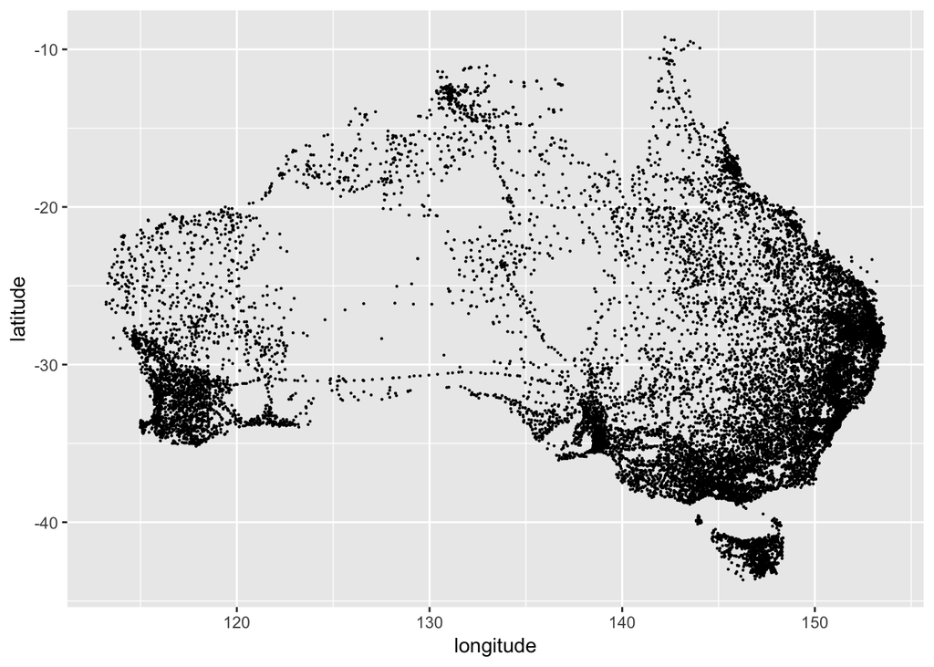

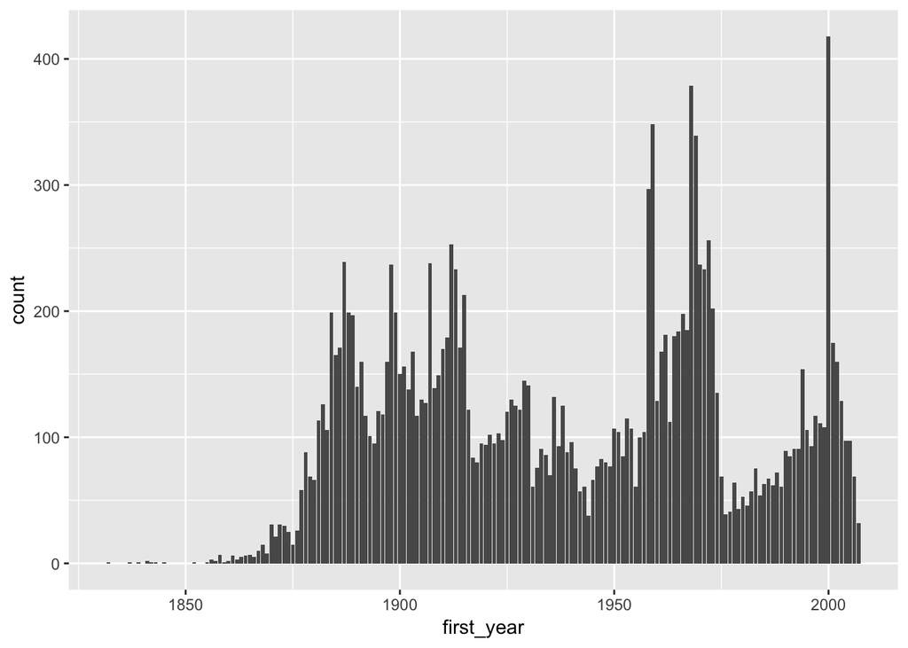

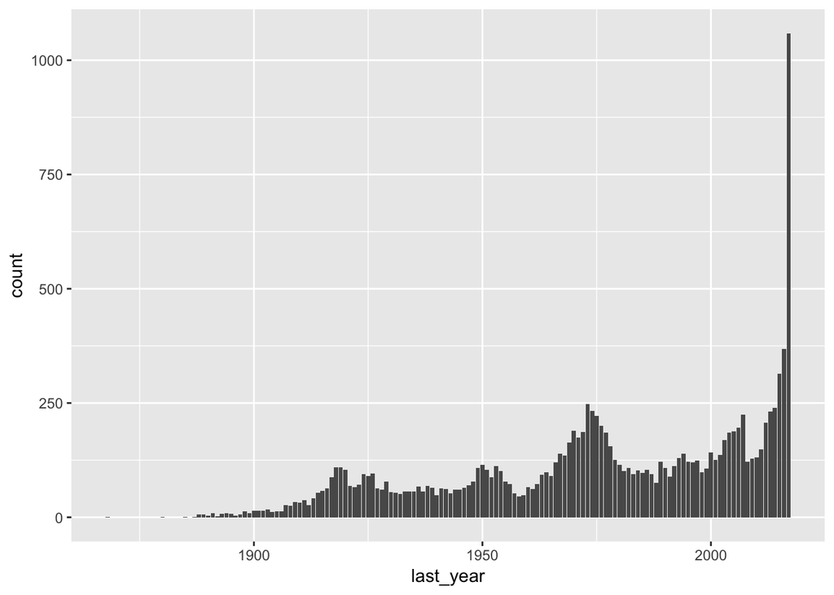

### 2. Get Rainfall Data

Once we know the station ID we are intersted in, we can get the station data from GHCN-Daily using the RNOAA package.

```r
stn_id = "ASN00040101"
prcp_var <- rnoaa::meteo_pull_monitors(stn_id,
                                date_min = "1910-01-01",
                                date_max = "2010-01-01",
                                keep_flags = TRUE,
                                var = "PRCP")
```

To save time, as getting data from the server can take a while, I have chosen to save the data. I save the data for the desired set of stn_ids into a file of the form `paste(data_dir, element_type, file_str, ".rds", sep ="")`. An example, file string is `paste("_xll_", bbox$xll, "_yll_", bbox$yll, "_dx_", dx, "_dy_", dy, ".rds", sep ="")`. There is a different file for each precipitation element type. Below is an example of how my wrapper works, into which you can pass all arguements from the `rnoaa::meteo_pull_monitors()` function.

```r
data_dir = "my_data_dir/"
file_str = "my_fav_stns"

# Restrict the date range to these dates
date_min = "1910-01-01"
date_max = "2017-12-31"

# Get the data from near my hometown
stn_ids = as_meta_data %>%
  dplyr::filter(longitude >= 152.6 & longitude < 152.8 &
                  latitude >= -27.7 & latitude < -27.5 &
                  element == "PRCP") %>%
  dplyr::select(id)  %>%
  unlist() %>%
  as.vector()

# Save out the data
wrapper_save_prcp_data(stn_ids = stn_ids, data_dir = data_dir, file_str =   file_str, date_min = date_min, date_max = date_max)
```

### 3. Get Nearby Neighbours

My application area is extremes, therefore it is important to address missingness within our precipitation data. Some studies use gridded observational products to interpolate missing values, however this can result in underestimating extremes. We have chosen instead to use the nearest neighbour infilling.

To can get all the stations within a given search radius we can use rnoaa::meteo_nearby_stations().

```r
stn_id = "ASN00040101"
search_radius = 10 #(km)

stn_lat_lon = as_meta_data %>%
  dplyr::filter(id == stn_id) %>%
  select(id, latitude, longitude) %>%
  distinct() %>%
  as.data.frame()

nearby_meta_data <- rnoaa::meteo_nearby_stations(lat_lon_df = stn_lat_lon,
                                          station_data = as_meta_data,
                                          var = "PRCP",
                                          year_min = 1910,
                                          radius = search_radius)[[1]]
```

We have saved the nearest neighbours within a 50 km radius of each station. See the helper file, `helper_get_nbrs.R`. We wrote an additional wrapper that saves the distances in `helper_dist_close_nbrs.R`.

# 4. Estimate Correlation

We only use nearest neighbour infilling if the neighbours are highly correlated. We estimate the correlation using spearmans rank correlation, given rainfall is skew and non-linear. The function to estimate the correlation is utils_correlation()

```r
stn_id = "ASN00040101"
search_radius = 10 #(km)

stn_lat_lon = as_meta_data %>%
  dplyr::filter(id == stn_id) %>%
  select(id, latitude, longitude) %>%
  distinct() %>%
  as.data.frame()

nearby_meta_data <- rnoaa::meteo_nearby_stations(lat_lon_df = stn_lat_lon,
                                          station_data = as_meta_data,
                                          var = "PRCP",
                                          year_min = 1910,
                                          radius = search_radius)[[1]]
nbr_ids = nearby_meta_data$id %>% unique()
nbr_ids = nbr_ids[2:4]

prcp_var <- rnoaa::meteo_pull_monitors(nbr_ids,
                                date_min = "1910-01-01",
                                date_max = "2010-01-01",
                                keep_flags = TRUE,
                                var = "PRCP")

prcp_spread = prcp_var %>%
    dplyr::filter(id %in% nbr_ids) %>%
    dplyr::filter(qflag_prcp == " ") %>%
    dplyr::select(date, id, prcp) %>%
    tidyr::spread(key = id, value = prcp) %>%
    dplyr::select(-date)

utils_correlation(prcp_spread, nbr_ids[1:2], type = "spearman")
```

```
## [1] NA
```

```r
utils_correlation(prcp_spread, nbr_ids[1:3], type = "spearman")
```

```
## [1] NA
```

We have saved the correlation for nearest neighbours within a 50 km radius of each station, see the helper file, `helper_get_corr.R`. (SLOW)

# 5. Add Reconstruction Column Data

We have written two functions to help with reconstruction. The first is recon_row(). An example of this function is given below.

```r
date = seq(as.Date("1910-01-01"), as.Date("1910-01-12"), by = "days")
id1 = rexp(length(date), rate = 1)
id2 = id1 + rnorm(length(date), 0, 1)
id3 = id1 + rnorm(length(date), 0.5, 2)
prcp_df = data.frame(date, id1, id2, id3)
prcp_df$id1[1:10] = NA
prcp_df$id2[1:5] = NA
prcp_df$id3[1] = NA
recon_row(prcp_df[1,])
```

```
##         date  id recon_prcp recon_flag
## 1 1910-01-01 id1         NA         NA
```

```r
recon_row(prcp_df[2,])
```

```
##         date  id recon_prcp recon_flag
## 2 1910-01-02 id1   4.542265        id3
```

```r
recon_row(prcp_df[6,])
```

```
##         date  id recon_prcp recon_flag
## 6 1910-01-06 id1 -0.6260004        id2
```

```r
recon_row(prcp_df[11,])
```

```
##          date  id recon_prcp recon_flag
## 11 1910-01-11 id1         NA         NA
```

```r
recon_df = NULL
for(i in 1:length(date)){
  recon_df = rbind(recon_df, recon_row(prcp_df[i, ]))
}
recon_df
```

```
##          date  id   recon_prcp recon_flag
## 1  1910-01-01 id1           NA       <NA>
## 2  1910-01-02 id1  4.542264632        id3
## 3  1910-01-03 id1  2.411636833        id3
## 4  1910-01-04 id1  7.568956588        id3
## 5  1910-01-05 id1  0.724313416        id3
## 6  1910-01-06 id1 -0.626000389        id2
## 7  1910-01-07 id1  0.154830853        id2
## 8  1910-01-08 id1  1.914274458        id2
## 9  1910-01-09 id1 -0.383827212        id2
## 10 1910-01-10 id1 -0.005026205        id2
## 11 1910-01-11 id1           NA       <NA>
## 12 1910-01-12 id1           NA       <NA>
```

The second, recon_stn(), loops over recon_row() and reconstructs the entire station record.

```r
date = seq(as.Date("1910-01-01"), as.Date("1910-01-31"), by = "days")
id1 = rexp(length(date), rate = 1)
id2 = id1 + rnorm(length(date), 0, 1)
id3 = id1 + rnorm(length(date), 0.5, 2)
prcp_df = data.frame(date, id1, id2, id3)
View(recon_stn(prcp_df))
prcp_df$id1[1:10] = NA
prcp_df$id2[1:5] = NA
prcp_df$id3[1] = NA
View(recon_stn(prcp_df))
View(recon_stn(prcp_df, delta_window = 3))
```

We have saved the reconstruction for each station, see the helper file, `helper_recon.R`.

## 7. Check for Sunday-Monday Untagged Accumulations

To check for untagged accumulations present amongst daily observations we use a test given in *Why It Never Rains on Sundays?* (Viney and Bates 2004). See the paper and documentation for the function `sun_mon_untagged_test()`.

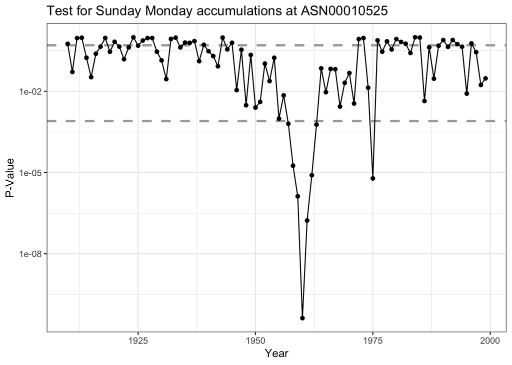

```r
stn_id = "ASN00010525" #"ASN00022000"

prcp_var <- meteo_pull_monitors(stn_id,
                                 date_min = "1910-01-01",
                                 date_max = "2000-01-01",
                                 keep_flags = TRUE,
                                 var = "PRCP")

dapr_var <- meteo_pull_monitors(stn_id,
                                 date_min = "1910-01-01",
                                 date_max = "2000-01-01",
                                 keep_flags = TRUE,
                                 var = "DAPR")

output <- sun_mon_untagged_test(prcp_var, dapr_var, stn_id)

ggplot(output, aes(x = block, y = p_value)) +
   geom_hline(yintercept = c(0.0008, 0.5), linetype = "dashed",
              col = "darkgray", size = 1.1) +
   geom_point() +
   geom_line() +
   scale_y_log10() +
   xlab("Year") +
   ylab("P-Value") +
   ggtitle(paste("Test for Sunday Monday accumulations at", stn_id)) +
   theme_bw()
```

Again we have written wrapper functions to run this test for multiple stations. The helper function, `helper_viney.R` reads in the saved data and then runs the wrapper function, `wrapper_viney.R`. The wrapper runs `sun_mun_untagged_test()` for a given vector of station IDs. We then save the output to another file to be processed later.